# AndresGibu_Tarea_Ejercicio_Series_Temporales

Andres Gibu

3/8/2020

## EJERCICIO DE EVALUACIÓN II

## ANÁLISIS Y PREDICCIÓN DE SERIES TEMPORALES

```r
setwd("C:/Users/andre/Documents/UCM/Mineria_de_datos_II/Evaluación")
library(readxl)
#Construcción de gráficas de series juntas
library(ggplot2)
library(ggfortify)
viajeros_pais_vasco<- read_excel("2074.xlsx" , sheet='Hoja1')
```

## Índice:

## 1. Introducción: Presentación de la serie a analizar. (1)

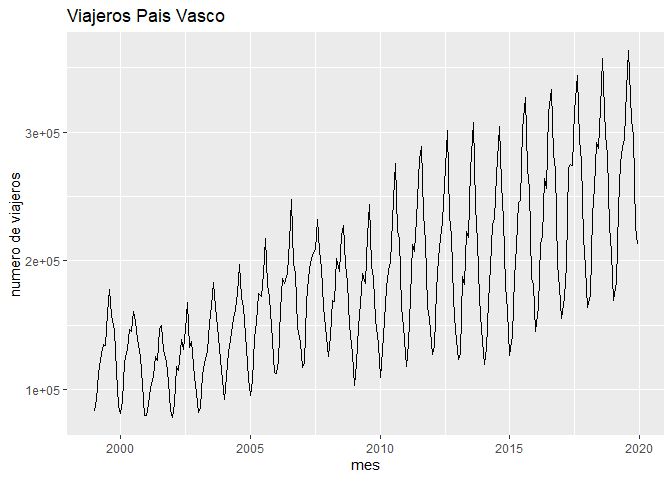

```r
viajeros<-ts(viajeros_pais_vasco[,-1], start = c(1999 ,1), frequency=12)
#Retiraremos los meses afectados por el covid-19
viajeros<-window(viajeros,start=c(1999 ,1), end=c(2019, 12))
autoplot(viajeros)+ ggtitle("Viajeros Pais Vasco") + xlab("mes") + ylab("numero de viajeros")
```

La serie es claramente no estacionaria, con tendencia creciente y estacional de 12 meses.

## 2. Representación gráfica y descomposición estacional (si tuviera comportamiento

## estacional). (1.5)

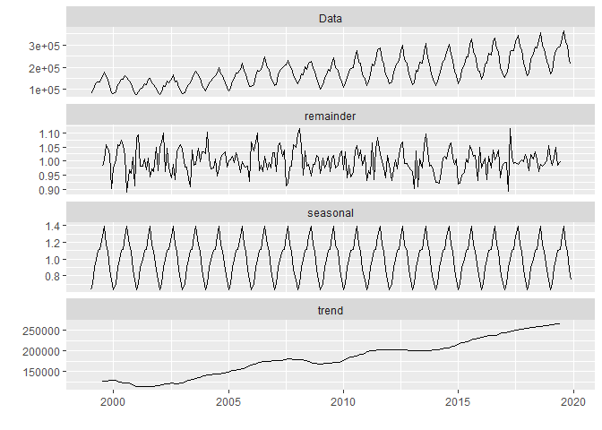

```r
#Guardamos los componentes de la descomposición estacional en
viajeros_Comp<- decompose(viajeros,type=c("multiplicative"))
#Representamos los componentes de la serie obtenidos.
autoplot(viajeros_Comp)
```

```r
library(forecast)
```

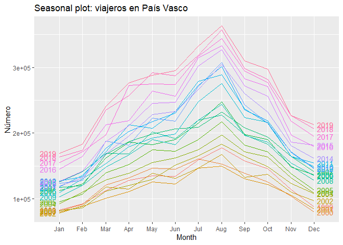

```r
ggseasonplot(viajeros, year.labels=TRUE, year.labels.left=TRUE) +
ylab("Número") +
ggtitle("Seasonal plot: viajeros en País Vasco")
```

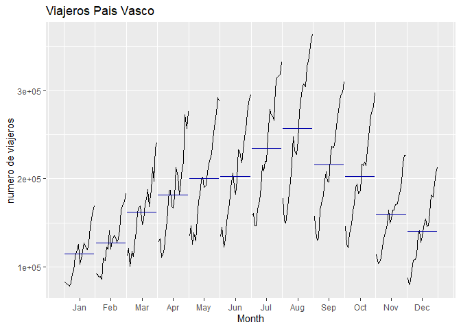

```r
ggsubseriesplot(viajeros) +
  ylab("numero de viajeros") +
  ggtitle("Viajeros Pais Vasco")
```

Vemos que no es estacionaria porque no tiene media constante, tiene tendencia creciente (trend) y es estacional con periodo 12 (seasonal).

El año con más viajeros fue 2019 justamente al ser tendencia creciente se da esto.

En el tercer gráfico podemos apreciar que el mes con más viajes es agosto y también se aprecia la estacionalidad

## 3. Para comprobar la eficacia de los métodos de predicción que vamos a hacer en los siguientes apartados reservamos los últimos datos observados (un periodo en las

## series estacionales o aproximadamente 10 observaciones) para comparar con las

## predicciones realizadas por cada uno de los métodos. Luego ajustamos los modelos

## sobre la serie sin esos últimos datos en los siguientes apartados

```r
# reservamos el ultimo año para comparar las prediciones
viajeros_train <- window(viajeros, end=c(2018,12))
#Vamos a predecir los valores que hemos reservado para test
h <- length(viajeros) - length(viajeros_train)
print(h)
```

```
## [1] 12
```

## 4. Encontrar el modelo de suavizado exponencial más adecuado. Para dicho modelo,

## representar gráficamente la serie observada y la suavizada con las predicciones para

## un periodo que se considere adecuado. (2)

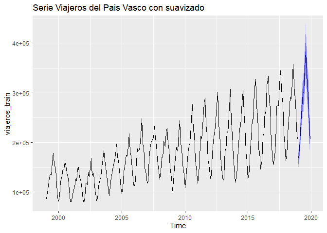

```r
viajeros_sh <- hw(viajeros_train,seasonal="multiplicative", h)
autoplot(viajeros_sh, main="Serie Viajeros del Pais Vasco con suavizado")
```

```r
print(viajeros_sh)
```

```
##          Point Forecast    Lo 80    Hi 80    Lo 95    Hi 95
## Jan 2019       167045.1 155474.9 178615.4 149350.0 184740.3
## Feb 2019       185710.2 172186.1 199234.4 165026.8 206393.7
## Mar 2019       239954.2 221653.9 258254.4 211966.3 267942.0
## Apr 2019       270342.0 248821.6 291862.5 237429.3 303254.7
## May 2019       298742.6 273990.8 323494.4 260888.0 336597.2
## Jun 2019       301596.9 275653.0 327540.9 261919.1 341274.8
## Jul 2019       351284.7 319978.4 382591.0 303405.8 399163.6
## Aug 2019       383263.6 347944.6 418582.6 329247.9 437279.3
## Sep 2019       317461.6 287261.7 347661.5 271274.9 363648.3
## Oct 2019       297284.8 268135.2 326434.5 252704.3 341865.4
## Nov 2019       233405.1 209847.7 256962.4 197377.2 269432.9
## Dec 2019       206242.9 184842.8 227643.0 173514.3 238971.5
```

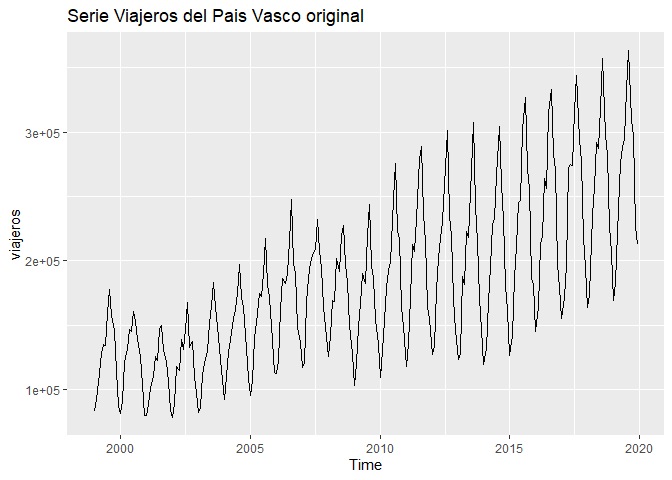

```r
serie_predicha_2019<-as.data.frame(viajeros_sh)

autoplot(viajeros, main="Serie Viajeros del Pais Vasco original")
```

```r
print(as.data.frame(window(viajeros, start=c(2019,1))))
```

```
##    Viajeros
## 1    169482
## 2    183447
## 3    240750
## 4    276648
## 5    288439
## 6    295071
## 7    332027
## 8    363162
## 9    309536
## 10   297055
## 11   226945
## 12   212801
```

```r
serie_original_2019<-as.data.frame(window(viajeros, start=c(2019,1)))
library(Metrics)
rmse(serie_predicha_2019$`Point Forecast`, serie_original_2019$Viajeros)
```

```
## [1] 9672.786
```

Comparamos PrintedForecast con la serie Viajeros y vemos que se aproximan bastante (RMSE=9672). Asimismo en la gráfica de serie podemos apreciar lo mismo.

# 5. Representar la serie y los correlogramas. Decidir que modelo puede ser ajustado.

# Ajustar el modelo adecuado comprobando que sus residuales están incorrelados.

# (Sintaxis, tablas de los parámetros estimados y gráficos) (3)

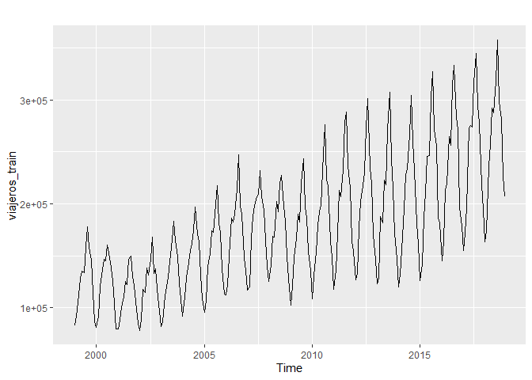

```r
autoplot(viajeros_train)
```

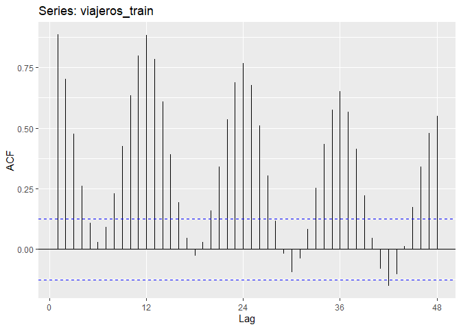

```r
#Calculamos las autocorrelaciones simples hasta el retardo 48
ggAcf(viajeros_train, lag=48)
```

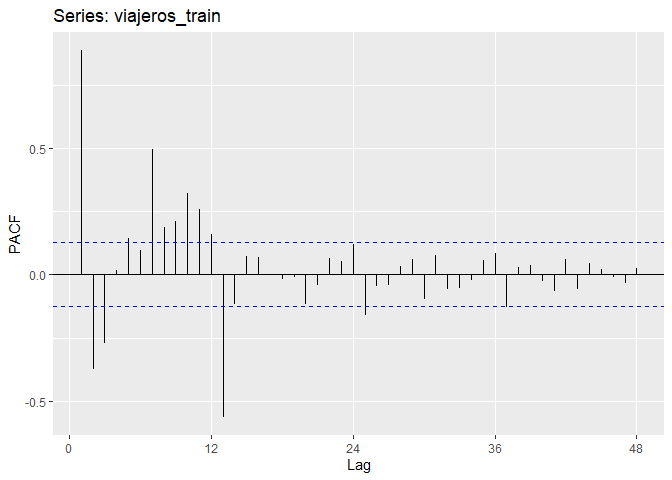

```r
#Calculamos las autocorrelaciones parciales hasta el retardo 48
ggPacf(viajeros_train, lag=48)
```

```r
2.
```

```
## [1] 2
```

En el correlalograma simple vemos que casi no decrece por lo que inferimos alta autocorrelación. La autocorrelación se da en los periodos 1 a 4 y luego del 8 al 12. En el correlalograma parcial ratificamos las conclusiones, vemos que hay alta correlacion hasta el periodo 13 por lo que podríamos decir que hay estacionalidad de 12 meses. Esto lo vimos en las gráficas por años donde la serie se incrementaba hasta el mes 8 y luego decrecia hasta el fin de año.

A continuación veamos como nos va con una diferenciación:

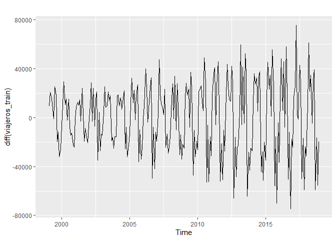

```r
autoplot(diff(viajeros_train))
```

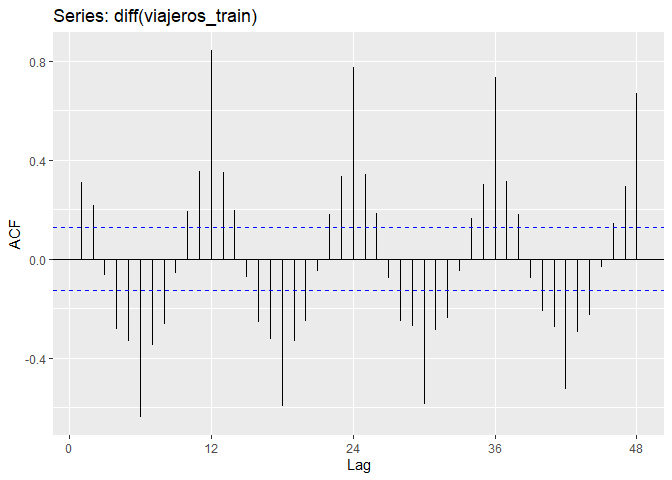

```r
ggAcf(diff(viajeros_train), lag=48)
```

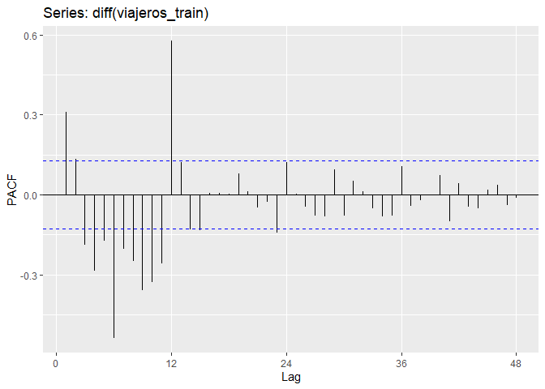

```r
ggPacf(diff(viajeros_train), lag=48)
```

La serie oscila alrededor de una media pero aún presenciamos autocorrelaciones a pesar de la diferenciación de un periodo con el anterior

A continuación veamos una diferenciación estacional:

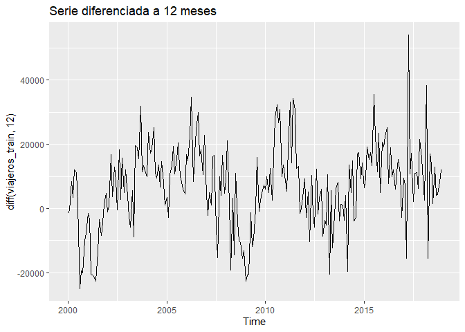

```r
autoplot(diff(viajeros_train,12),main="Serie diferenciada a 12 meses")
```

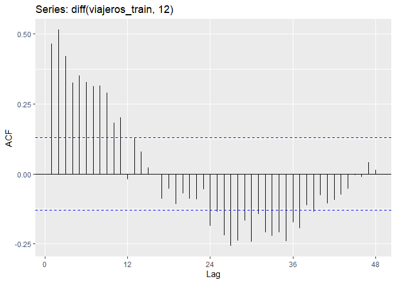

```r
ggAcf(diff(viajeros_train,12), lag=48)
```

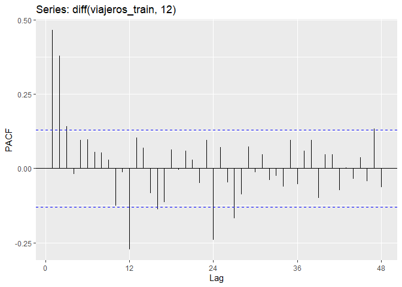

```r
ggPacf(diff(viajeros_train,12), lag=48)
```

Luego de aplicar la diferenciación de 12 meses, hemos quitado la estacionalidad. EL correlalograma simple mejora ya que decrece más rápidamente y el correlalograma parcial indica que hay autocorrelación hasta el periodo 2 más una débil en el tres -AR(3)- y en cuanto a la estacionalidad hay picos cada 12 meses hasta el mes 24 -MA(2).

Con ello ajustaremos a un modelo ARIMA del tipo (3,0,0)(0,1,2)

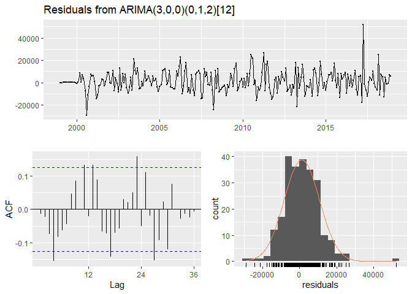

```
##
##  Ljung-Box test
##
## data:  Residuals from ARIMA(3,0,0)(0,1,2)[12]
## Q* = 42.752, df = 19, p-value = 0.001401
##
## Model df: 5.   Total lags used: 24
```

```r
#Ajuste del ARIMA(3,0,0)(0,1,2)
fitvviajeros <- Arima((viajeros_train),c(3,0,0),seasonal=c(0,1,2))
checkresiduals(fitvviajeros)
```

```r
fitvviajeros
```

```
## Series: (viajeros_train)
## ARIMA(3,0,0)(0,1,2)[12]
##
## Coefficients:
##          ar1     ar2     ar3     sma1     sma2
##       0.3797  0.3859  0.1356  -0.4140  -0.0468
## s.e.  0.0712  0.0652  0.0671   0.0748   0.0682
##
## sigma^2 estimated as 99200449:  log likelihood=-2421.82
## AIC=4855.64   AICc=4856.02   BIC=4876.21
```

El p-value es pequeño, quizá no está ajustando muy bien y el Alkaike para diferenciación AICc es alto. La gráfica de ACF para los residuos todavía tiene picos que salen del intervalo de confianza.

Veamos con la función auto.arima

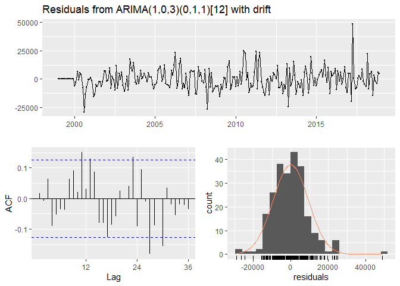

```
##
##  Ljung-Box test
##
## data:  Residuals from ARIMA(1,0,3)(0,1,1)[12] with drift
## Q* = 38.09, df = 18, p-value = 0.003769
##
## Model df: 6.   Total lags used: 24
```

```r
fitvviajeros2 <- auto.arima((viajeros_train), seasonal=TRUE,stepwise=FALSE, approximation=FALSE)
checkresiduals(fitvviajeros2)
```

```r
fitvviajeros2
```

```
## Series: (viajeros_train)
## ARIMA(1,0,3)(0,1,1)[12] with drift
##
## Coefficients:
##          ar1      ma1     ma2      ma3     sma1     drift
##       0.9361  -0.6212  0.1740  -0.1587  -0.4652  579.2814
## s.e.  0.0378   0.0821  0.0874   0.0698   0.0669  174.0878
##
## sigma^2 estimated as 95237070:  log likelihood=-2416.57
## AIC=4847.13   AICc=4847.64   BIC=4871.14
```

Mejoró ligeramente pero aún no es sufiencite para obtener residuos dentro del intervalo de confianza.

Vemos cómo nos va reduciendo variabilidad, empleamos primero un logaritmo:

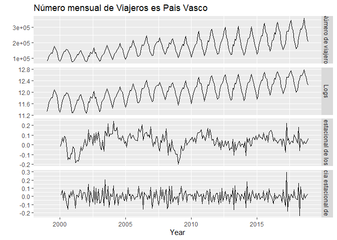

```r
cbind("Número de viajeros" = viajeros_train,
      "Logs" = log(viajeros_train),
      "Diferencia estacional de los logaritmos" =
        diff(log(viajeros_train),12),
      "Doble Diferencia estacional de los logaritmos" =
        diff(diff(log(viajeros_train),12),1)) %>%
  autoplot(facets=TRUE) +
    xlab("Year") + ylab("") +
    ggtitle("Número mensual de Viajeros es Pais Vasco")
```

Nos apoyaremos en unos test para inferir si corresponde hacer diferenciaciones:

```r
library(urca)
viajeros_train %>% ur.kpss() %>% summary()
```

```
##
## #######################
## # KPSS Unit Root Test #
## #######################
##
## Test is of type: mu with 4 lags.
##
## Value of test-statistic is: 3.1005
##
## Critical value for a significance level of:
##                 10pct  5pct 2.5pct  1pct
## critical values 0.347 0.463  0.574 0.739
```

```r
#Revisamos si es necesaria una diferenciacion estacional
viajeros_train %>% log() %>% nsdiffs()
```

```
## [1] 1
```

```r
#[1] 1

#Revisamos si es necesaria una diferenciacion con el periodo anterior luego de aplicar diferenciacion estacional
viajeros_train %>% log() %>% diff(lag=12) %>% ndiffs()
```

```
## [1] 0
```

```r
#[1] 0

# viajeros_train %>% log() %>% ndiffs()
# #[1] 1
# viajeros_train %>% log() %>% diff(lag=1) %>% nsdiffs()
# #[1] 1
```

Claramente la data es no estacionaria y el test lo comprueba. Respecto a la necesidad de diferenciación estacional sobre el logaritmo de la serie, sí es necesaria al tener un estadístico >0.64 Rescto a la necesidad de hacer una diferenciación siguiente no es necesaria

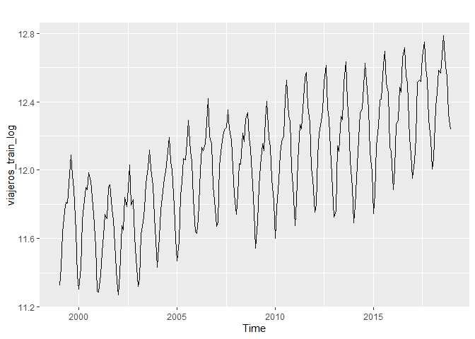

```r
viajeros_train_log<-log(viajeros_train)

autoplot(viajeros_train_log)
```

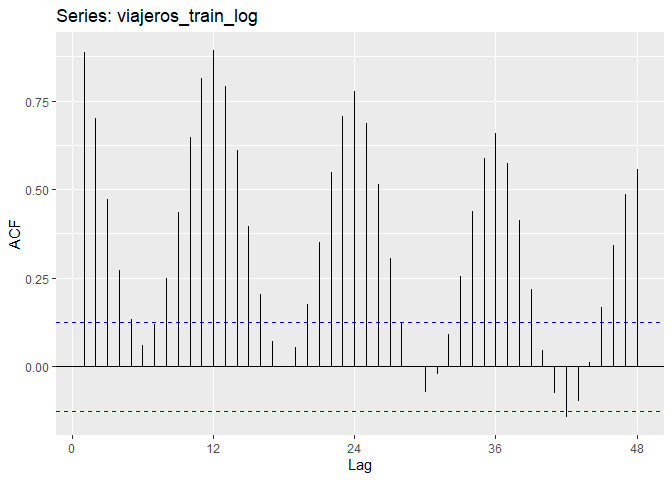

```r
ggAcf(viajeros_train_log, lag=48)
```

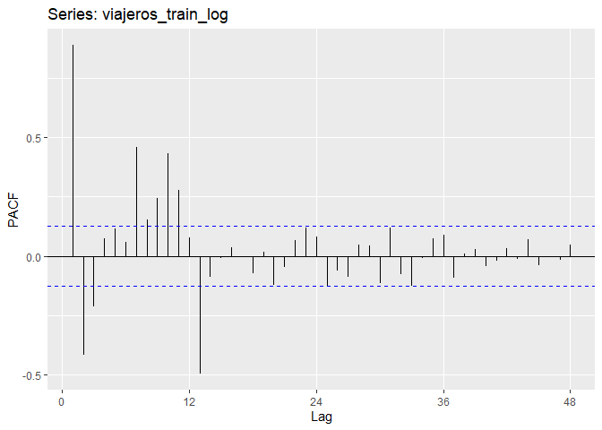

```r
ggPacf(viajeros_train_log, lag=48)
```

Aplicaremos una diferenciacion estacional luego de reducir la variabilidad:

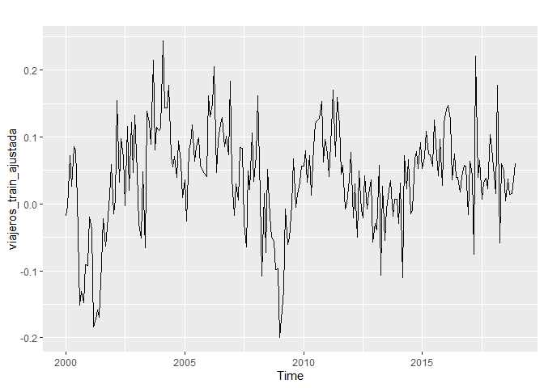

```r
viajeros_train_ajustada<-diff(viajeros_train_log,12)

autoplot(viajeros_train_ajustada)
```

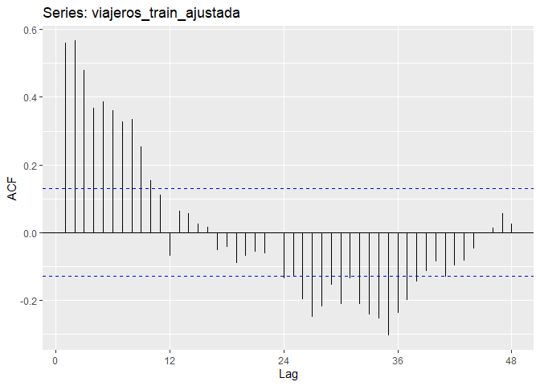

```r
ggAcf(viajeros_train_ajustada, lag=48)
```

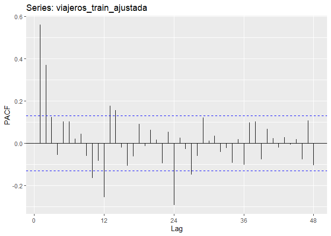

```r
ggPacf(viajeros_train_ajustada, lag=48)
```

El ajuste manual de la serie:

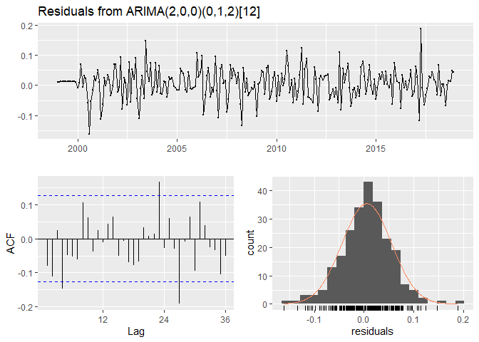

```
##
##  Ljung-Box test
##
## data:  Residuals from ARIMA(2,0,0)(0,1,2)[12]
## Q* = 30.887, df = 20, p-value = 0.05671
##
## Model df: 4.   Total lags used: 24
```

```r
#Ajuste del ARIMA(2,0,0)(0,1,2)
fitvviajeros <- Arima((viajeros_train_log),c(2,0,0),seasonal=c(0,1,2))
checkresiduals(fitvviajeros)
```

```r
fitvviajeros
```

```
## Series: (viajeros_train_log)
## ARIMA(2,0,0)(0,1,2)[12]
##
## Coefficients:
##          ar1     ar2     sma1     sma2
##       0.4972  0.4716  -0.6697  -0.1044
## s.e.  0.0592  0.0584   0.0718   0.0692
##
## sigma^2 estimated as 0.002673:  log likelihood=348.72
## AIC=-687.43   AICc=-687.16   BIC=-670.28
```

Con el Modelo ARima propuesto se logró un bajo AICc por lo que se podría tomar este modelo por encima del modelo que se realizó sin quitar variabilidad con logaritmos.

Ahora utilizaremos la función auto.arima

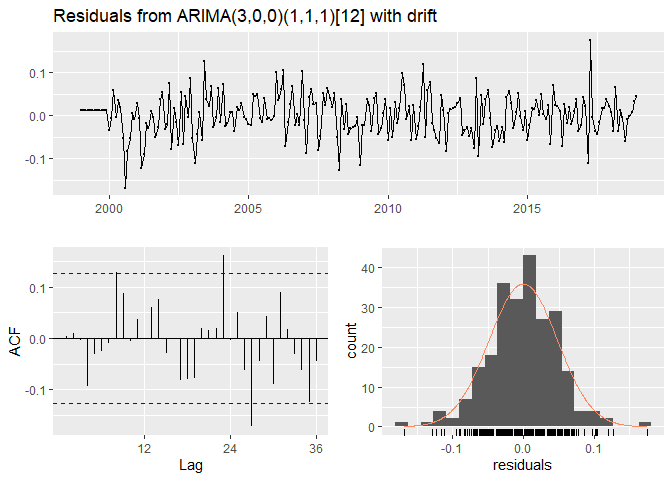

```
##
##  Ljung-Box test
##
## data:  Residuals from ARIMA(3,0,0)(1,1,1)[12] with drift
## Q* = 24.068, df = 18, p-value = 0.1528
##
## Model df: 6.   Total lags used: 24
```

```r
fitvviajeros2 <- auto.arima(viajeros_train_log, seasonal=TRUE,stepwise=FALSE, approximation=FALSE)
checkresiduals(fitvviajeros2)
```

```r
fitvviajeros2
```

```
## Series: viajeros_train_log
## ARIMA(3,0,0)(1,1,1)[12] with drift
##
## Coefficients:
##          ar1     ar2     ar3    sar1     sma1   drift
##       0.3734  0.3475  0.1067  0.1908  -0.8471  0.0033
## s.e.  0.0664  0.0668  0.0662  0.0931   0.0640  0.0004
##
## sigma^2 estimated as 0.002511:  log likelihood=356.38
## AIC=-698.76   AICc=-698.25   BIC=-674.76
```

Obtuvimos un p-value mayor que el manual (bastante mayor también al estadístico de 0.05 con los que los residuos están incorrelados) y el AICc un poco menor (-698.25 vs -687.16 con lo que el ajuste es mejor). La serie de residuos tiene menos picos que caen fuera del intervalo de confianza (2 vs 3 picos).

A continuación veamos cómo nos va con una transformación de boxcox en vez de usar logaritmo:

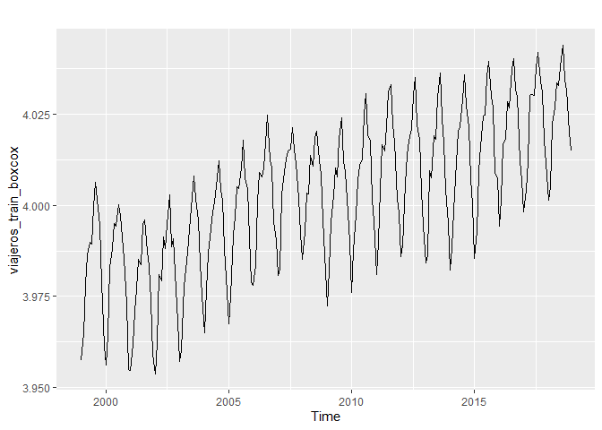

```r
lambda <- BoxCox.lambda(viajeros_train)

viajeros_train_boxcox<-BoxCox(viajeros_train,lambda)

autoplot(viajeros_train_boxcox)
```

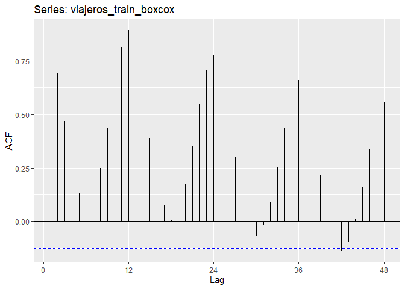

```r
ggAcf(viajeros_train_boxcox, lag=48)
```

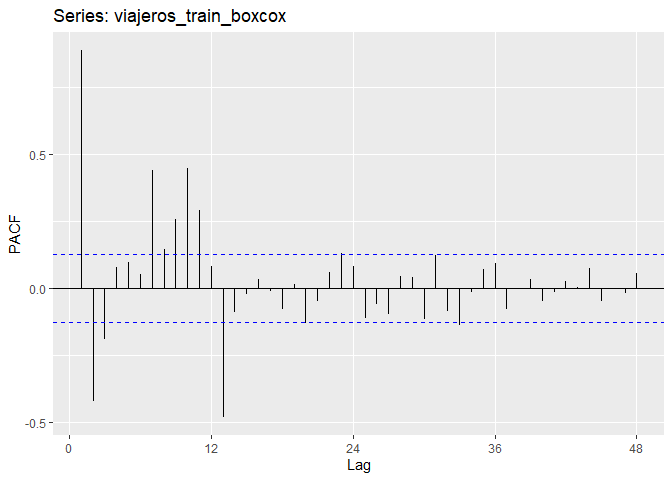

```r
ggPacf(viajeros_train_boxcox, lag=48)
```

Veamos los test para diferenciaciones:

```r
library(urca)
viajeros_train %>% ur.kpss() %>% summary()
```

```
##
## #######################
## # KPSS Unit Root Test #
## #######################
##
## Test is of type: mu with 4 lags.
##
## Value of test-statistic is: 3.1005
##
## Critical value for a significance level of:
##                 10pct  5pct 2.5pct  1pct
## critical values 0.347 0.463  0.574 0.739
```

```r
#Revisamos si es necesaria una diferenciacion estacional
viajeros_train_boxcox %>% nsdiffs()
```

```
## [1] 1
```

```r
#[1] 1

#Revisamos si es necesaria una diferenciacion con el periodo anterior luego de aplicar diferenciacion estacional
viajeros_train_boxcox %>% diff(lag=12) %>% ndiffs()
```

```
## [1] 0
```

```r
#[1] 0

# viajeros_train %>% log() %>% ndiffs()
# #[1] 1
# viajeros_train %>% log() %>% diff(lag=1) %>% nsdiffs()
# #[1] 1
```

Respecto a la necesidad de diferenciación estacional sobre la transformada de la serie, sí es necesaria al tener un estadístico >0.64 Rescto a la necesidad de hacer una diferenciación siguiente no es necesaria